# Non-linearity in Reaction Time Data

Nicolas Restrepo

2/17/2020

## Are non linear models more appropriate here?

Here, I am going to explore whether the relationship between distance from the prototype and reaction could be better expressed non-linearly. Let me begin by importing the data and reshaping it.

Let’s begin by thinking about the expected relationships between the variables. We have two pieces of information that should be informative when predicting reaction time: distance from the prototype and ambiguity. The latter should be conceived as how much agreement there was amongst respondents that an event was either immoral or harmful. We can envision two measures for this: either the proportion of events that were classified as either harmful or immoral or the variance of the same measure. Let’s explore these correlation between these variables.

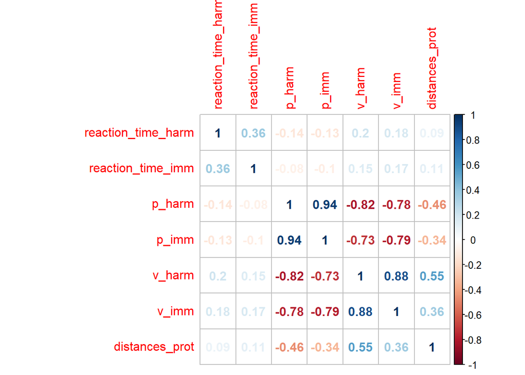

The correlations look as we expected. As distance from the prototype increases, the proportions of harm and immorality decrease. Expectedly, the opposite (but mirroring) relationship occurs for the variances of harm and immorality: more ambiguous scenarios tend to be further away from the prototype. The relationships between these variables and reaction time, however, seem rather week. It might be perhaps that these relationships are non-linear.

Let’s think about non-linearity in terms of distance from the prototype and reaction time. If we posit that this relationship is linear, then implicitly argue that every unit of distance away from the template should result in a commesurate increase in reaction time. Instead, we can think about fuzzy categories as gravitational fields. Initially, distance from the template should be positively related with cognitive effort. However, there must be a tipping point after which events start seemingly obviously not immoral; the point at which you have left the gravitational pull of the category. The relationship, in this case, would be described as a parabola. Additionally, we could think about this relationship logarithmically. Initial moves away from the prototype should have a big impact on cognitive effort. As distance increases, though, the effect of moving further away becomes increasingly smaller.

Similarly, we can envision similar non-linear relationships between reaction time and “ambiguity” - i.e. proportion of respondents who said an event was either harmful or immoral. We can imagine for instance that people categorize quickly unambiguous events, whether they are immoral or not. This would, then, also be expressed by a quadratic expression.

We can test these models but before it would be useful to visualize the data to see whether these relationships are indeed plausible.

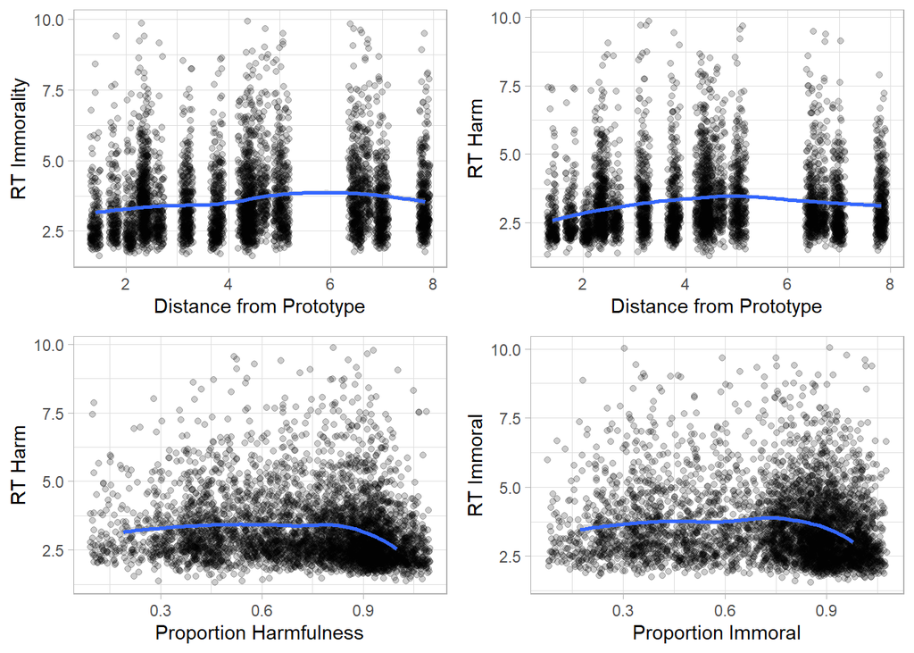

The data show that non-linearity is certainly plausible. Now, I am going to test which model best reflects the relationship between distance from the prototype and reaction time.

|  | reaction time harm |  |  |
| --- | --- | --- | --- |
| Predictors | Estimates | CI | p |
| (Intercept) | 2.02 | 1.21 – 2.82 | **<0.001** |
| distances_prot | 0.04 | -0.02 – 0.10 | 0.201 |
| length | 0.03 | 0.01 – 0.06 | **0.016** |
| Random Effects |  |  |  |
| σ<sup>2</sup> | 1.08 |  |  |
| τ<sub>00</sub> <sub>ids</sub> | 0.38 |  |  |
| τ<sub>00</sub> <sub>scenario</sub> | 0.08 |  |  |
| ICC | 0.30 |  |  |
| N <sub>ids</sub> | 184 |  |  |
| N <sub>scenario</sub> | 25 |  |  |
| Observations | 4600 |  |  |
| Marginal R<sup>2</sup> / Conditional R<sup>2</sup> | 0.020 / 0.312 |  |  |

|  | reaction time harm |  |  |
| --- | --- | --- | --- |
| Predictors | Estimates | CI | p |
| (Intercept) | 1.41 | 0.66 – 2.15 | **<0.001** |
| distances_prot | 0.52 | 0.24 – 0.79 | **<0.001** |
| distances_prot^2 | -0.05 | -0.08 – -0.02 | **0.001** |
| length | 0.02 | -0.00 – 0.05 | 0.057 |
| Random Effects |  |  |  |
| σ<sup>2</sup> | 1.08 |  |  |
| τ<sub>00</sub> <sub>ids</sub> | 0.38 |  |  |
| τ<sub>00</sub> <sub>scenario</sub> | 0.05 |  |  |
| ICC | 0.28 |  |  |
| N <sub>ids</sub> | 184 |  |  |
| N <sub>scenario</sub> | 25 |  |  |
| Observations | 4600 |  |  |
| Marginal R<sup>2</sup> / Conditional R<sup>2</sup> | 0.037 / 0.311 |  |  |

|  | reaction time harm |  |  |
| --- | --- | --- | --- |
| Predictors | Estimates | CI | p |
| (Intercept) | 1.97 | 1.20 – 2.74 | **<0.001** |
| distances_prot [log] | 0.24 | 0.00 – 0.47 | **0.050** |
| length | 0.03 | 0.00 – 0.06 | **0.026** |
| Random Effects |  |  |  |
| σ<sup>2</sup> | 1.08 |  |  |
| τ<sub>00</sub> <sub>ids</sub> | 0.38 |  |  |
| τ<sub>00</sub> <sub>scenario</sub> | 0.07 |  |  |
| ICC | 0.29 |  |  |
| N <sub>ids</sub> | 184 |  |  |
| N <sub>scenario</sub> | 25 |  |  |
| Observations | 4600 |  |  |
| Marginal R<sup>2</sup> / Conditional R<sup>2</sup> | 0.024 / 0.311 |  |  |

```
##    df      BIC
## m1  6 13958.05
## m2  7 13963.27
## m3  6 13953.27
```

If we compare the measures of fit, the model that best captures the relationship in the data is the linear-log model. We can plot these relationship to better understand it.

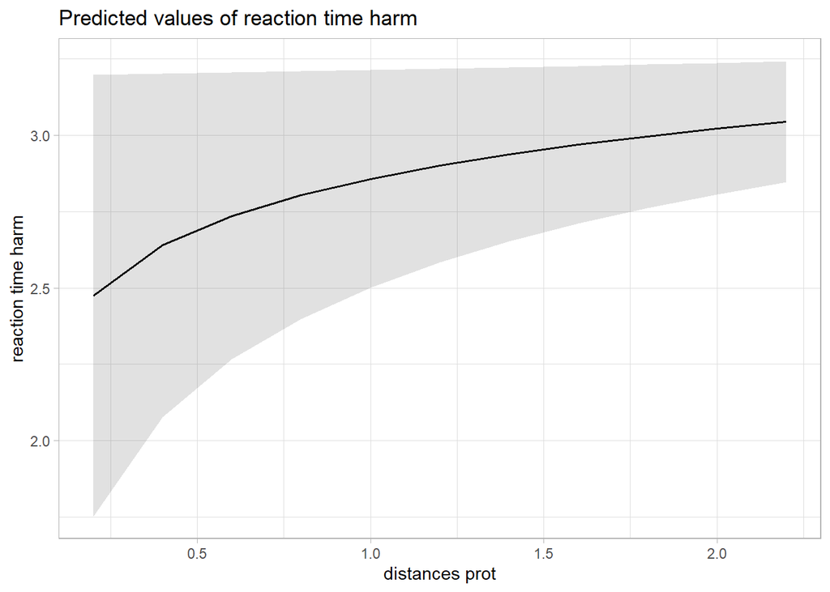

We see that the non-linear relationship looks as expected. Initial moves away from the template are “costly” but then the impact of distance plateaus. This certainly reflects current understandings of how mental templates aid categorization.

Now, let’s look at the relationship between ambiguity and reaction time, comparing the different ways of expressing this relationship.

|  | reaction time harm |  |  |
| --- | --- | --- | --- |
| Predictors | Estimates | CI | p |
| (Intercept) | 2.64 | 1.92 – 3.37 | **<0.001** |
| p_harm | -0.77 | -1.18 – -0.36 | **<0.001** |
| length | 0.04 | 0.02 – 0.06 | **0.001** |
| Random Effects |  |  |  |
| σ<sup>2</sup> | 1.08 |  |  |
| τ<sub>00</sub> <sub>ids</sub> | 0.38 |  |  |
| τ<sub>00</sub> <sub>scenario</sub> | 0.05 |  |  |
| ICC | 0.28 |  |  |
| N <sub>ids</sub> | 184 |  |  |
| N <sub>scenario</sub> | 25 |  |  |
| Observations | 4600 |  |  |
| Marginal R<sup>2</sup> / Conditional R<sup>2</sup> | 0.036 / 0.310 |  |  |

|  | reaction time harm |  |  |
| --- | --- | --- | --- |
| Predictors | Estimates | CI | p |
| (Intercept) | 1.68 | 1.02 – 2.35 | **<0.001** |
| length | 0.03 | 0.01 – 0.04 | **0.001** |
| p_harm | 3.62 | 1.74 – 5.51 | **<0.001** |
| p_harm^2 | -3.36 | -4.79 – -1.94 | **<0.001** |
| Random Effects |  |  |  |
| σ<sup>2</sup> | 1.08 |  |  |
| τ<sub>00</sub> <sub>ids</sub> | 0.38 |  |  |
| τ<sub>00</sub> <sub>scenario</sub> | 0.02 |  |  |
| ICC | 0.27 |  |  |
| N <sub>ids</sub> | 184 |  |  |
| N <sub>scenario</sub> | 25 |  |  |
| Observations | 4600 |  |  |
| Marginal R<sup>2</sup> / Conditional R<sup>2</sup> | 0.052 / 0.309 |  |  |

|  | reaction time harm |  |  |
| --- | --- | --- | --- |
| Predictors | Estimates | CI | p |
| (Intercept) | 1.92 | 1.19 – 2.65 | **<0.001** |
| p_harm [log] | -0.35 | -0.60 – -0.09 | **0.008** |
| length | 0.04 | 0.01 – 0.06 | **0.002** |
| Random Effects |  |  |  |
| σ<sup>2</sup> | 1.08 |  |  |
| τ<sub>00</sub> <sub>ids</sub> | 0.38 |  |  |
| τ<sub>00</sub> <sub>scenario</sub> | 0.06 |  |  |
| ICC | 0.29 |  |  |
| N <sub>ids</sub> | 184 |  |  |
| N <sub>scenario</sub> | 25 |  |  |
| Observations | 4600 |  |  |
| Marginal R<sup>2</sup> / Conditional R<sup>2</sup> | 0.029 / 0.311 |  |  |

```
##    df      BIC
## m4  6 13944.91
## m5  7 13936.74
## m6  6 13950.40
```

Here the relationship is most appropriately described as quadratic. Respondents categorize unambiguous events more quickly, at either side of the moral spectrum.

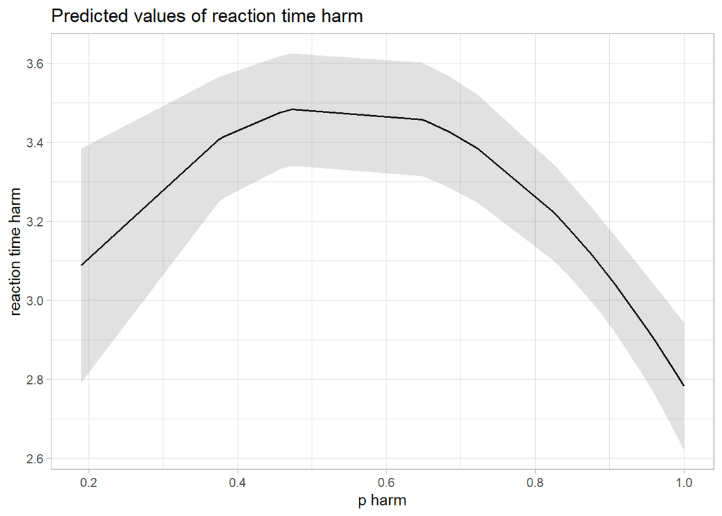

## What is the relationship between ambiguity and distance from the prototype?

My first instinct was to put all these variables into the model predicting reaction time. Nonetheless, I wonder whether this is fundamentally at odds with the mechanism we are positing here. Ultimately, the argument we are trying to test is whether the attribution of immorality occurs is explained by distance from a cognitive template. In this model, then, the ambiguity of an event must be the result of its distance to a prototype; after all this is the cognitive presupposition we are buying into. “Controlling” for the proportion of respondents who found an event immoral would imply a causal model in which we think that ambiguity affects both distance from the prototype and reaction time:

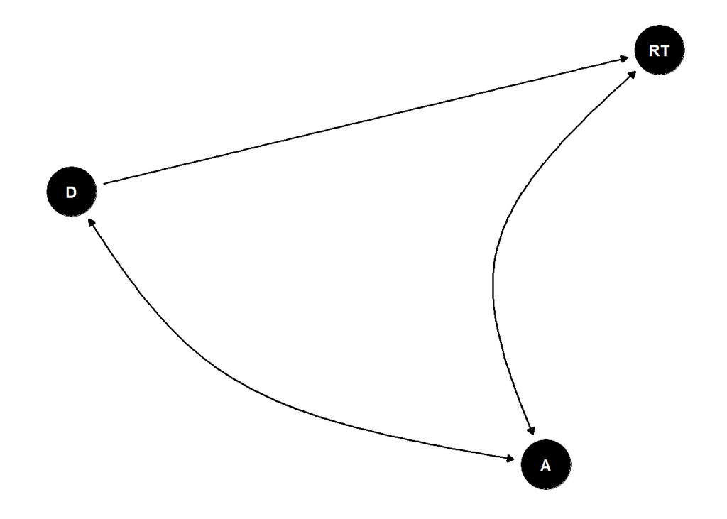

This is, however, not consistent with our model of moral cognition. If prototypical categorization is the underlying mechanism then ambiguity is a necessarily an effect of distance itself. The model would look more like this:

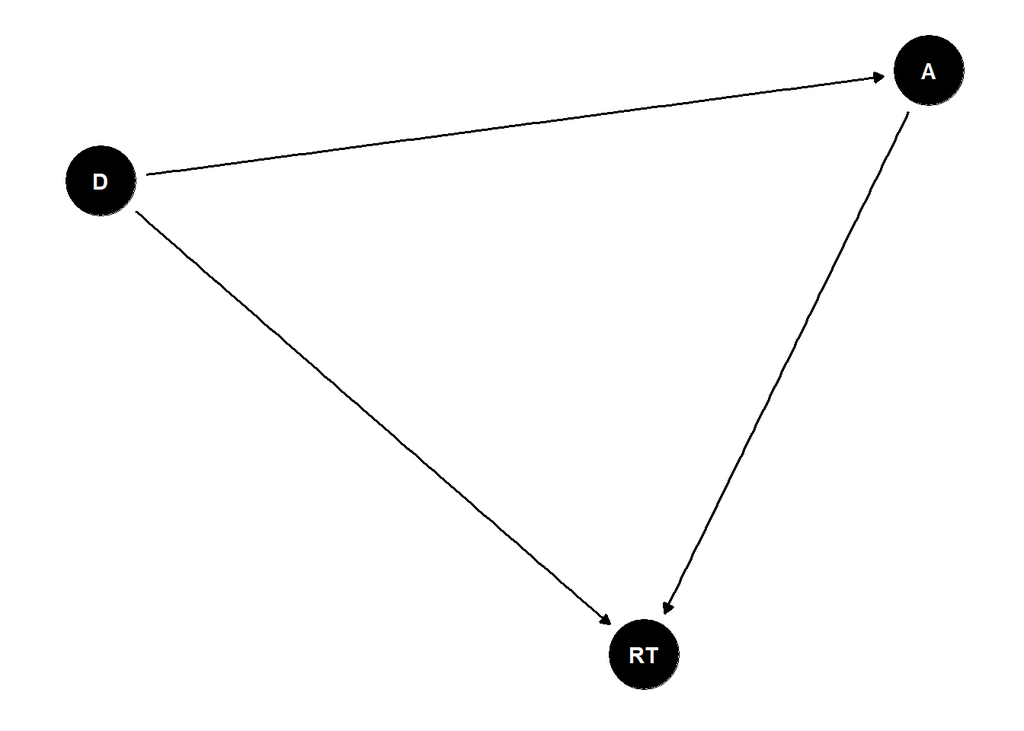

This diagram fits better with our thinking thorughout this project. One question we could ask then is whether distance affects reaction time mainly through ambiguity. But I am not sure whether that statement is purely circular.